# Time Series Homework: Chapter 4 Lesson 1

## Questions

### Question 1 - Key Definitions (10 points)

Answer the prompt to the learning outcome below. Include any mathematical expressions or illustrations that may accompany the definitions and ideas if available.

**Answer**

- **Define Gaussian white noise**
- **State DWN second order properties**
- **State the assumptions needed to categorize residual error series as white noise**
- **Define a random walk**

### Question 2 - Gaussian White Noise (25 points)

1. Simulate a realization of Gaussian White Noise and plot it. Use 25 points and $\sigma^2=1$

**Answer**

2. Estimate the second order properties of the sample. Why don’t they match exactly with the parameters you set to create it?

**Answer**

3. Simulate a realization of Gaussian White Noise and plot it. Use 500 points and $\sigma^2=1$

**Answer**

4. Estimate the second order properties of the sample in part c. Contrast your results with part b? Please explain your results.

**Answer**

### Question 3 - Random Walks (45 points)

1. Simulate a realization of a white noise process using the Exponential distribution. If $s_t$ is the realization from an exponentially distributed random variable, use the white noise $w_t=s_t-\lambda$ for your simulation. The length of the series is 500 points and $\lambda=1$. Please plot your simulation.

**Answer**

2. Superimpose a histogram of the Gaussian White noise simulation from Question 2 versus the Exponential White Noise. Please compare and contrast the two distributions. Your chart should look close to Figure 1 below. *Hint: research exponential random variables and their right-tail properties.*

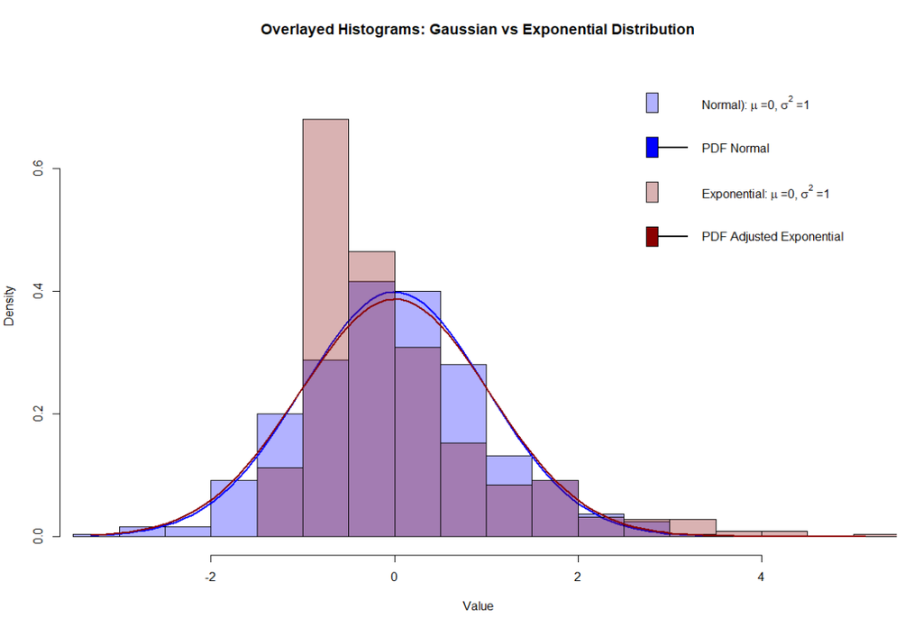

**Answer**

3. Suppose you were to create two random walk series using the Gaussian and Exponential DWN simulations. How do you think they would differ from one another?

**Answer**

4. Create two random walk series using the Gaussian and Exponential DWN simulations. Plot them together. Are there some conclusions you can draw from comparing the series? *Hint: you might want to generate multiple samples before you start making observations.*

**Answer**

### Rubric

[output not shown]